# Whole Game

R for Data Science Chapters 1-8

Julianne G. Clina, PhD

University of Kansas Medical Center

June 24, 2026

## Welcome to the R-Lab!!!

**Goal:** get just enough of every major data science tool to tackle a real dataset, start to finish.

**The data science cycle:**

Import → Tidy → **Transform ⇄ Visualize ⇄ Model** → Communicate

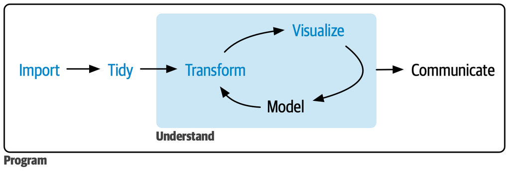

## Today’s Plan

**Workflow basics**

- Naming, style, scripts, projects
- These habits show up in every lesson going forward, so we won’t repeat them

**The four tools**

- Import data → readr
- Tidy data → tidyr
- Transform data → dplyr
- Visualize data → ggplot2

We’re covering this in **import → tidy → transform → visualize** order today (rather than the book’s order) because that’s the order you actually touch a new dataset.

## The Whole Game, Explained Like a Kitchen

Think of data science like cooking a meal:

| Data science step | Kitchen analogy |
| --- | --- |
| Import | Grocery shopping |
| Tidy | Washing & chopping ingredients |
| Transform | Cooking & seasoning |
| Visualize | Plating the dish |
| Communicate | Serving it to others |

You *can’t* plate raw ingredients, and you *shouldn’t* cook before you chop.

# Workflow: The Habits That Make This Easier

## Naming Things and Writing Code

### Who are you writing code for?

- Not your professor
- Not your classmates
- **Future you (who has forgotten everything)**

If code only makes sense *right now*, it will absolutely fail you in 2 weeks.

```r
# Assignment uses <- (shortcut: Alt/Option + -)
x <- 3 * 4
primes <- c(2, 3, 5, 7, 11, 13)
```

**Strive for:**

```r
short_flights <- flights %>%
  filter(air_time < 60)
```

**Avoid:**

```r
SHORTFLIGHTS <- flights %>%
  filter(air_time < 60)

short.flights <- flights %>%
  filter(air_time < 60)

ShortFlights <- flights %>%
  filter(air_time < 60)
```

**snake_case**, spaces around `<-` and operators, and `%>%` at the **end** of a line (not the start) — these three habits make code dramatically easier to read later.

## Scripts and Projects

- Write code in the **script editor**, not just the console — Cmd/Ctrl + Enter runs a line, Cmd/Ctrl + Shift + S runs the whole script
- Keep every project (data, scripts, outputs) together using an **RStudio Project** (`.Rproj`)
- For those using Positron, this is set up for you by working in a specific workspace (folder)
- Use **relative paths** (`data/students.csv`), never absolute ones (`/Users/you/...`) — relative paths work on anyone’s machine

```r
# Good — relative to the project folder
write_csv(diamonds, "data/diamonds.csv")
```

Restart R often (Cmd/Ctrl + Shift + 0) and re-run your script from scratch. If it still works, your **script**, not your environment, is the real source of truth.

# Importing Data

## Reading Data In With readr

```r
library(tidyverse)

students <- read_csv(
  "data/students.csv",
  na = c("N/A", "") # treat "N/A" strings as real missing values
)
```

readr guesses each column’s type (logical → number → date → string) from a sample of rows, and prints what it guessed — always worth a glance.

**Common cleanup after import:**

- `janitor::clean_names()` → tidy up column names to snake_case
- `mutate(x = factor(x))` → turn categorical text into a factor
- `parse_number()` → pull a number out of a messy string column

Other formats: `read_tsv()`, `read_delim()`, multiple files at once with `read_csv(list.files(...), id = "file")`.

# Tidying Data

## What Makes Data “Tidy”?

> “Tidy datasets are all alike, but every messy dataset is messy in its own way.” — Hadley Wickham

**Three rules:**

1. Each variable is a column.
2. Each observation is a row.
3. Each value is a cell.

Tidy data is what lets dplyr and ggplot2 “just work” — most real-world data isn’t tidy yet, which is why `tidyr` exists.

## Reshaping With `pivot_longer()` / `pivot_wider()`

**Too wide** — values trapped in column names (e.g. a column per week)

```r
billboard %>%
  pivot_longer(
    cols = starts_with("wk"),
    names_to = "week",
    values_to = "rank",
    values_drop_na = TRUE
  )
```

**Too long** — one observation spread across multiple rows

```r
cms_patient_experience %>%
  pivot_wider(
    id_cols = starts_with("org"),
    names_from = measure_cd,
    values_from = prf_rate
  )
```

# Transforming Data

## dplyr: One Grammar for Rows, Columns, and Groups

Every dplyr verb: (1) takes a data frame first, (2) refers to columns by bare name, (3) returns a new data frame.

| Acts on | Verbs |
| --- | --- |
| **Rows** | `filter()`, `arrange()`, `distinct()` |
| **Columns** | `mutate()`, `select()`, `rename()`, `relocate()` |
| **Groups** | `group_by()`, `summarize()`, `slice_max()` / `slice_min()` |

**Before** — `flights`, untouched:

```r
head(flights)
```

```
# A tibble: 6 × 19
   year month   day dep_time sched_dep_time dep_delay arr_time sched_arr_time
  <int> <int> <int>    <int>          <int>     <dbl>    <int>          <int>
1  2013     1     1      517            515         2      830            819
2  2013     1     1      533            529         4      850            830
3  2013     1     1      542            540         2      923            850
4  2013     1     1      544            545        -1     1004           1022
5  2013     1     1      554            600        -6      812            837
6  2013     1     1      554            558        -4      740            728
# ℹ 11 more variables: arr_delay <dbl>, carrier <chr>, flight <int>,
#   tailnum <chr>, origin <chr>, dest <chr>, air_time <dbl>, distance <dbl>,
#   hour <dbl>, minute <dbl>, time_hour <dttm>
```

## dplyr in Action: Before → After

**The pipeline:**

```r
fast_iah <- flights |>
  filter(dest == "IAH") %>%
  mutate(speed = distance / air_time * 60) %>%
  select(year:day, dep_time, carrier, speed) %>%
  arrange(desc(speed))
```

**After** — filtered to `IAH`, new `speed` column, fewer columns, sorted:

```r
head(fast_iah)
```

```
# A tibble: 6 × 6
   year month   day dep_time carrier speed
  <int> <int> <int>    <int> <chr>   <dbl>
1  2013     7     9      707 UA       522.
2  2013     8    27     1850 UA       521.
3  2013     8    28      902 UA       519.
4  2013     8    28     2122 UA       519.
5  2013     6    11     1628 UA       515.
6  2013     8    27     1017 UA       515.
```

Read `%>%` or `|>` as **“then.”** This pipeline reads: take flights, *then* filter, *then* mutate, *then* select, *then* arrange.

## Grouped Summaries

```r
flights %>%
  group_by(month) %>%
  summarize(
    avg_delay = mean(dep_delay, na.rm = TRUE),
    n = n()
  )
```

💡 **Always include `n()`** alongside any summary statistic. A mean from 3 observations and a mean from 3,000 observations look identical in a table — but you should trust them very differently.

```r
# Newer shortcut — group for just this one operation
flights %>%
  summarize(delay = mean(dep_delay, na.rm = TRUE), n = n(), .by = month)
```

# Visualizing Data

## ggplot2: The Grammar of Graphics

> “The simple graph has brought more information to the data analyst’s mind than any other device.” — John Tukey

Every plot: **data** + **mapping** (`aes()`) + **geom**.

Let’s build one up layer by layer so you can see exactly what each piece adds.

## Building a Plot, Layer by Layer (1/4)

Start with **data** + **mapping** — `aes()` just sets up the coordinate system, no geometry yet:

```r
library(palmerpenguins)
ggplot(penguins, aes(x = flipper_length_mm, y = body_mass_g))
```

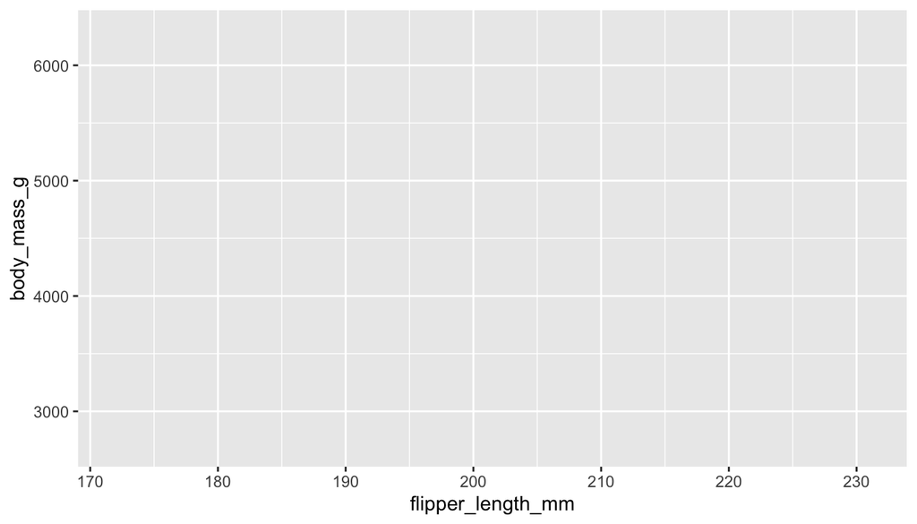

Nothing plots yet — `ggplot()` + `aes()` only declares *what goes where*, not *how to draw it*.

## Building a Plot, Layer by Layer (2/4)

Add a **geom** — now there’s something to look at:

```r
ggplot(penguins, aes(x = flipper_length_mm, y = body_mass_g)) +
  geom_point()
```

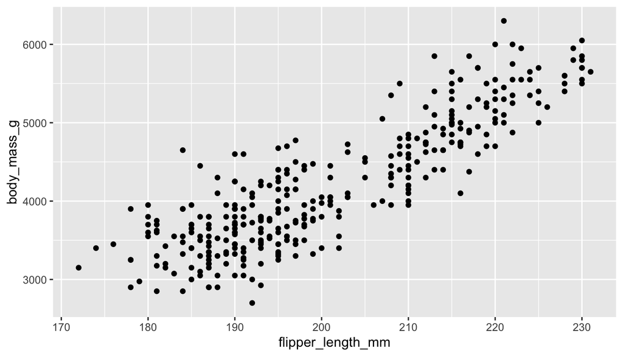

## Building a Plot, Layer by Layer (3/4)

Map **species** to `color` and `shape` — a third variable, no new geom required:

```r
ggplot(penguins, aes(x = flipper_length_mm, y = body_mass_g)) +
  geom_point(aes(color = species, shape = species))
```

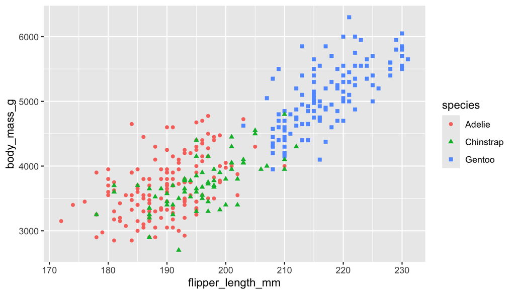

## Building a Plot, Layer by Layer (4/4)

Add a second **geom** — `geom_smooth()` layers a trend line on top:

```r
ggplot(penguins, aes(x = flipper_length_mm, y = body_mass_g)) +
  geom_point(aes(color = species, shape = species)) +
  geom_smooth(method = "lm")
```

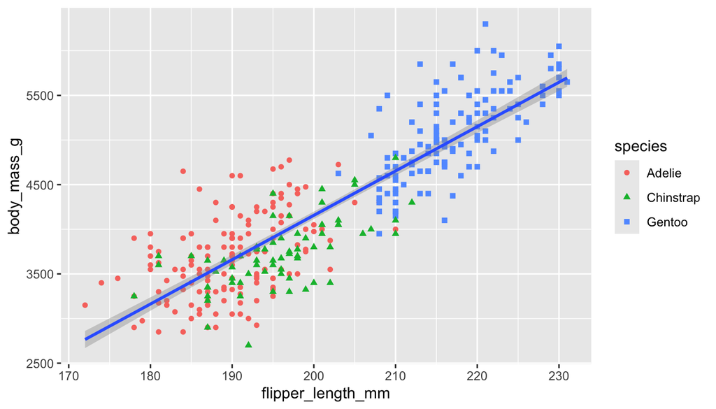

Every plot is **data** + **mapping** (`aes()`) + one or more **geoms** — each `+` stacks another layer on the same coordinate system.

## Matching Plot Type to Question

| Question | Geom(s) |
| --- | --- |
| One categorical variable | `geom_bar()` |
| One numerical variable | `geom_histogram()`, `geom_density()` |
| Numerical vs. categorical | `geom_boxplot()` |
| Two numerical variables | `geom_point()`, `geom_smooth()` |
| 3+ variables | extra aesthetics (`color`, `shape`) **or** `facet_wrap()` |

```r
# Faceting beats cramming too many aesthetics onto one plot
ggplot(penguins, aes(x = flipper_length_mm, y = body_mass_g)) +
  geom_point(aes(color = species)) +
  facet_wrap(~island)
```

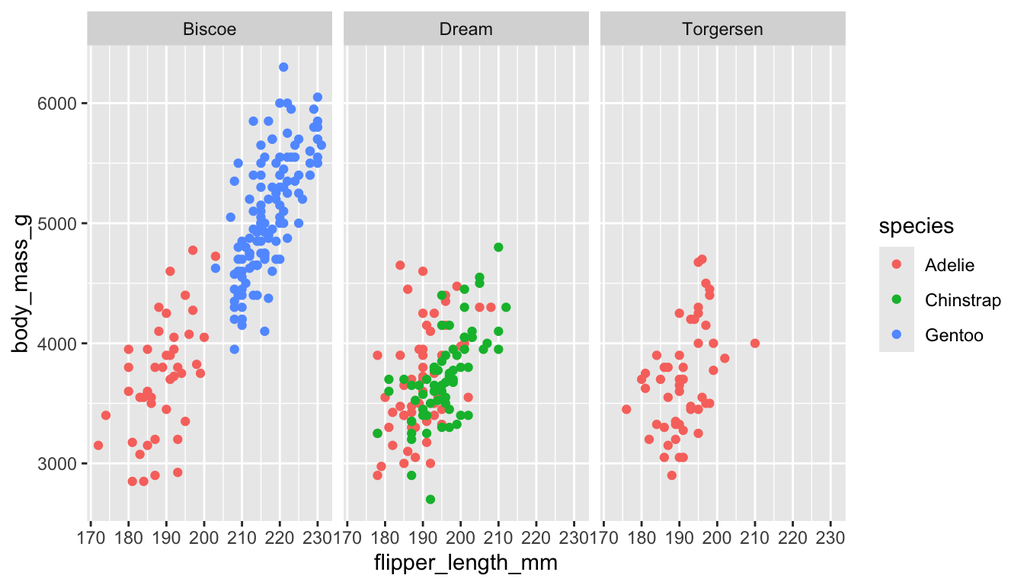

*map* a variable to an aesthetic when you want it to **vary** by data; *set* it (`color = "blue"`) when you just want a fixed look.

## Polishing and Saving

```r
ggplot(penguins, aes(x = flipper_length_mm, y = body_mass_g)) +
  geom_point(aes(color = species, shape = species)) +
  geom_smooth(method = "lm") +
  labs(
    title = "Body mass and flipper length",
    x = "Flipper length (mm)",
    y = "Body mass (g)",
    color = "Species",
    shape = "Species"
  )

ggsave("penguin-plot.png")
```

Same styling rules from the workflow section apply here: treat `+` like `%>%` — space before it, end of the line, one argument per line once it gets long.

# Bringing It All Together

## A Realistic Pipeline

```r
library(tidyverse)

flights_summary <- read_csv("data/flights.csv") %>% # import
  drop_na(dep_delay, arr_delay) %>% # tidy / clean
  filter(month %in% 6:8) %>% # transform
  group_by(carrier) %>%
  summarize(avg_delay = mean(dep_delay), n = n())

ggplot(flights_summary, aes(x = carrier, y = avg_delay)) + # visualize
  geom_col()
```

This is the whole game in five lines: **import → tidy → transform → visualize.** Everything else in the book is depth on one of these four steps.

# Getting Help

## When You’re Stuck

1. **Google it** — add “R” or a package name to your search
2. **Search Stack Overflow** — include the `[R]` tag
3. **Still stuck? Build a reprex** — a minimal, self-contained example someone else can copy, paste, and run

```r
reprex::reprex()
```

80% of the time, just *writing* a clean minimal example reveals the bug yourself before anyone has to answer it.

## Summary

**The four tools:** `readr` (import) → `tidyr` (tidy) → `dplyr` (transform) → `ggplot2` (visualize)

**The habits that make it sustainable:** descriptive names, consistent style, RStudio projects with relative paths, restarting R often, and knowing how to ask for help.

We’ll go much deeper on each of these tools in upcoming lessons — today was about seeing how they fit together.

## In-Class Activity: Your First GitHub Push

Goal for the remainder of the meeting: Everyone will…

- Edit a file in *their own folder*
- Push it to GitHub
- See it render online

## Step 1: Fork the Repository

Open the class repo on Github:

1. Click **Fork**
2. Accept all defaults
3. Wait for GitHub to finish

You should now see the repo under **your username**

## Step 2: Clone Your Fork

From *your fork* on GitHub:

1. Click **Code**
2. Copy the HTTPS URL or Open it GitHub Desktop
3. In RStudio or Positron:
   - Clone repository
   - Paste the URL
   - Open the project

## Step 3: Navigate to Your Folder

Inside the project (on your computer in Positron), go to:

- attendees/
- YourName/
- code

## Step 4: Create a Simple Quarto Document

Inside your `code/` folder:

Create a file called: whole-game.qmd

Paste this: as the YAML

```yaml
---
title: "The Whole Game Practice"
format: html
---
```

Create an R Code Chunk and enter:

```r
# Hello R-LAB

message("My first GitHub push worked!")

x <- 1:10
mean(x)
```

And Save the file!

## Step 5: Render with Quarto Locally

- Open your .qmd files
- In the terminal or console, run:

`quarto render`

- This creates the HTML and confirms it’s correct!

## Step 6: Commit & Push!

- Open GitHub Desktop
- You should see your .qmd file listed as a change
- Add a message and description
- Click **Commmit to Main**
- ClicK **Push Origin**

You should now see your file on GitHub!

## Step 7: Enable GitHub Pages

Within **your fork** on GitHub.com

1. Click *Settings*
2. Click *Pages*
3. Under *Source*  
   + Branch: main  
   + Folder: /(root)
4. Click *Save*

You should get a Pages URL, which you can preview. Navigate to your folder to preview it!

## Step 8: Create a Pull Request

This will allow you to merge your work into the class repository. From **your fork** on GitHub

1. Click *Contribute*
2. Click *Open pull request*
3. Confirm the information is correct
4. Click *Create pull request*
5. Add a title and description with a clear message  
   + Title: Whole Game Practice (Your Name)  
   + Description: - added whole-game.qmd